# ch05 - Log Scale Visualisation

2020-07-29T00:10:39+09:00

## 공지

- 본 포스트는 [데이터 시각화 교과서](http://www.yes24.com/Product/Goods/87631760) 내용의 일부를 요약하였다.

[figure not shown]

- 본 포스트를 읽고 가급적 전체 내용 숙지를 위해 구매하는 것을 권유한다.

## 개요

- 수치형 자료를 `Y`축으로 놓는 그래프는 언제나 힘들었다.
- `log Scale`을 통해 값의 크기를 줄이기는 하지만, `Y`축을 어떻게 표현하는 것이 좋을지에 대한 고민은 늘 있어왔다.
- 시각화 이론 중심의 포스팅이기에 코드 리뷰 및 해석은 생략한다.

## 문제점

- `log Scale`을 적용했을 때와 그렇지 않을 때의 그래프를 비교해본다.

### (1) 패키지 불러오기

- 각각의 패키지를 불러온다.
- 이 때, 데이터는 `dviz.supp` 저자인 `Claus O. Wilke`의 `Github Repo`에서 가져와야 한다.
  - 경고: 이 부분이 초급자 분들에게는 쉽지가 않다.
- 우선, 사전에 설치해야 할 패키지가 존재한다.
- 현재 필자 개발환경 Spec은 다음과 같다.

```r
> sessionInfo()
R version 4.0.2 (2020-06-22)
Platform: x86_64-apple-darwin17.0 (64-bit)
Running under: macOS Catalina 10.15.6
```

- 아래는 추가적으로 설치한 파일이다.
  - 깃허브 Issues에서 좀 더 구체적으로 확인하는 것을 추천한다.
  - 참조: [installation instructions? #2](https://github.com/clauswilke/dviz.supp/issues/2)

```r
install.packages("devtools")

devtools::install_github("wilkelab/cowplot")
library(cowplot)

install.packages("colorspace")
library(colorspace)

devtools::install_github("clauswilke/colorblindr")
library(colorblindr)

devtools::install_github("clauswilke/dviz.supp")
library(dviz.supp)
```

- 위 패키지들을 설치하는데 꽤 시간이 걸렸다.

```r
library(lubridate) # 날짜 관련 패키지
library(forcats)   # 시계열 관련 패키지
library(tidyr)     # 데이터 핸들링 패키지
library(ggrepel)   # 시각화 관련 패키지
library(dviz.supp) # 저자의 개인 Repo 패키지: 교재 있는 데이터 활용 및 그래프를 구현하려면 필수적으로 설치 되어야 함.
library(kableExtra) # 데이터 출력 Table을 HTML로 변환하기 위한 패키지
```

### (2) 데이터 확인

- 데이터는 `US_Census` 데이터를 기반으로 한다.
  - 자료 출처: 2010년도 미국 10개년 인구조사
- 주의: 한글 폰트는 일단 생략했다.

> 소스코드 참조: https://github.com/clauswilke/dataviz/blob/master/coordinate_systems_axes.Rmd

```r
set.seed(3878)

US_census %>% filter(state == "Texas") %>%
  select(name, pop2010) %>%
  extract(name, "county", regex = "(.+) County") %>%
  mutate(popratio = pop2010/median(pop2010)) %>%
  arrange(desc(popratio)) %>%
  mutate(index = 1:n(),
         label = ifelse(index <= 3 | index > n()-3 | runif(n()) < .04, county, ""),
         label_large = ifelse(index <= 6, county, "")) -> tx_counties

kable(tx_counties) %>%
  kable_styling(bootstrap_options = c("striped", "hover")) %>%
  scroll_box(width = "500px", height = "200px")
```

| county | pop2010 | popratio | index | label | label_large |
| --- | --- | --- | --- | --- | --- |
| Harris | 4092459 | 222.6461564 | 1 | Harris | Harris |
| Dallas | 2368139 | 128.8362439 | 2 | Dallas | Dallas |
| Tarrant | 1809034 | 98.4186932 | 3 | Tarrant | Tarrant |
| Bexar | 1714773 | 93.2905174 | 4 |  | Bexar |
| Travis | 1024266 | 55.7241717 | 5 |  | Travis |
| El Paso | 800647 | 43.5584027 | 6 |  | El Paso |
| Collin | 782341 | 42.5624830 | 7 |  |  |
| Hidalgo | 774769 | 42.1505359 | 8 |  |  |
| Denton | 662614 | 36.0488548 | 9 |  |  |
| Fort Bend | 585375 | 31.8467439 | 10 |  |  |
| Montgomery | 455746 | 24.7944073 | 11 |  |  |
| Williamson | 422679 | 22.9954301 | 12 |  |  |
| Cameron | 406220 | 22.0999946 | 13 |  |  |
| Nueces | 340223 | 18.5094935 | 14 |  |  |
| Brazoria | 313166 | 17.0374844 | 15 |  |  |
| Bell | 310235 | 16.8780262 | 16 |  |  |
| Galveston | 291309 | 15.8483760 | 17 | Galveston |  |
| Lubbock | 278831 | 15.1695229 | 18 | Lubbock |  |
| Jefferson | 252273 | 13.7246613 | 19 |  |  |
| Webb | 250304 | 13.6175399 | 20 |  |  |
| McLennan | 234906 | 12.7798270 | 21 |  |  |
| Smith | 209714 | 11.4092813 | 22 |  |  |
| Brazos | 194851 | 10.6006746 | 23 |  |  |
| Hays | 157107 | 8.5472499 | 24 |  |  |
| Johnson | 150934 | 8.2114140 | 25 |  |  |
| Ellis | 149610 | 8.1393831 | 26 |  |  |
| Ector | 137130 | 7.4604211 | 27 |  |  |
| Midland | 136872 | 7.4463849 | 28 |  |  |
| Guadalupe | 131533 | 7.1559219 | 29 |  |  |
| Taylor | 131506 | 7.1544530 | 30 |  |  |

[output cut: 224 more lines]

### (3) 모호한 시각화

- 주어진 데이터를 가지고 시각화를 작성한다.

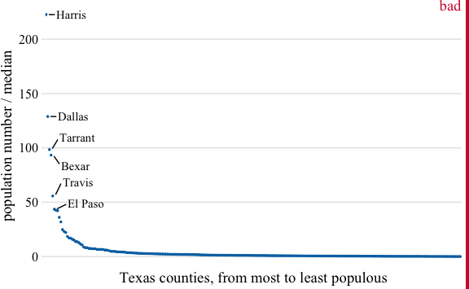

```r
temp_font <- "Times New Roman"

counties_lin <- ggplot(tx_counties, aes(x = index, y = popratio)) +
  geom_point(size = 0.5, color = "#0072B2") +
  geom_text_repel(aes(label = label_large), point.padding = .4, color = "black",
                  min.segment.length = 0, family = temp_font) +
  scale_y_continuous(name = "population number / median") +
  scale_x_continuous(limits = c(.5, nrow(tx_counties) + .5), expand = c(0, 0),
                     breaks = NULL, #c(1, 50*(1:5)),
                     name = "Texas counties, from most to least populous") +
  theme_dviz_hgrid(font_family = temp_font) +
  theme(axis.line = element_blank(),
        plot.margin = margin(3, 7, 3, 1.5))

ggdraw(counties_lin, clip = "on") +
  draw_text(paste0("bad", "  "), x=1, y=1, vjust=1.1, hjust=1, size=14, angle = 0,
              color="#d02138", alpha=1, family = temp_font, fontface = "plain") +
  draw_line(c(1, 1), c(0, 1), size=2.8, color="#d02138", alpha=1)
```

- 위 그래프는 전형적인 선형 스케일을 옮겨 담은 것이다.
  - `선형(linear)스케일`은 대개 데이터를 정확하게 보여주기도 하지만, 독자에게 보다 강한 메시지를 주기 위해서는 비선형 스케일이 더 좋을 때가 있다.
  - 위 데이터에서 인구 수가 중간값이 카운티와 중간 값에 훨씬 못 미치는 카운티 사이의 인구 차이가 잘 드러나지 않으면, 전달력이 그만큼 떨어진다는 얘기다.

## 로그 스케일 적용

- 로그 변환을 적용한 그래프를 작성한다.
- 그래프를 먼저 본 후, 추가적인 이론 설명을 진행한다.

### (1) 보정된 시각화

- 시각화 코드는 아래와 같다.

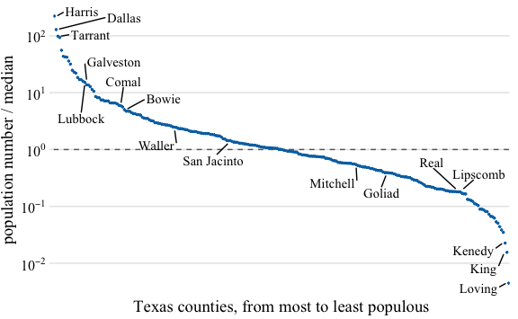

```r
ggplot(tx_counties, aes(x = index, y = popratio)) +
  geom_hline(yintercept = 1, linetype = 2, color = "grey40") +
  geom_point(size = 0.5, color = "#0072B2") +
  geom_text_repel(aes(label = label), point.padding = .4, color = "black",
                  min.segment.length = 0, family = temp_font) +
  scale_y_log10(breaks = c(.01, .1, 1, 10, 100),
                name = "population number / median",
                labels = label_log10) +
  scale_x_continuous(limits = c(.5, nrow(tx_counties) + .5), expand = c(0, 0),
                     breaks = NULL, #c(1, 50*(1:5)),
                     name = "Texas counties, from most to least populous") +
  theme_dviz_hgrid(font_family = temp_font) +
  theme(axis.line = element_blank(),
        plot.margin = margin(3, 7, 3, 1.5))
```

### (2) 그래프 해석

- 위 그래프는 비율 값을 로그 스케일로 사용할 때의 예시이다. - 텍사스의 카운티별 인구를 텍사스 전체 인구의 중간 값으로 나눈다고 생각할 때, 이 계산으로 얻은 비율 값은 1보다 크거나 작다.
  - 다시 말하면, 비율 값이 정확하게 1이면 그 카운티는 텍사즈 주 전체의 중간 값과 똑같다고 볼 수 있다.
- 대칭 형태의 그래프를 보여주면서, 인구가 많은 지역과 그렇지 못한 지역의 편차를 보여주는 매우 훌륭한 그래프가 완성 되었다.
- 지역별로 편차가 심하게 큰 데이터에는 로그스케일 변환 그래프가 유용할 수 있다.
- 해리스의 카운티는 4,092,459명이지만, 가장 적은 카운티는 82명일 수도 있다.
- 이러한 경우에 로그 스케일은 매우 적정할 수 있다.

### (3) 제곱근 스케일

- 만약 특정지역의 인구수가 0명으로 기록되었다면 어떻게 할까?
- 0은 로그 스케일에 표시할 수 없기 때문에, 이럴 경우 제곱근 스케일을 사용한다.
- 그러나, 다루기가 쉽지 않다.
  - 이 부분은 교재 또는 추후에 별도로 포스팅 하는 것으로 남겨둔다.

## 소결론

- 시각화를 그릴 때, 표준점수로 환산해서 그래프를 작성한 적은 몇번 있다.
  - 막대 그래프를 사용했지만, 거리감까지 드는 그래프는 아니었다.
  - 위 그래프는 line + point의 조합으로 나타냈다는 데 의의가 있다.
- 선형 스케일, 로그 스케일, 그리고 제곱근 스케일의 차이점이 있음을 알게 되었다.

> 자세한 건 교재를 구매하자.

## V. Reference (원서)

Wilke, C. (2019). Fundamentals of Data Visualization. Retrieved July 28, 2020, from https://serialmentor.com/dataviz/